# Forschungszentrum-Jülich algal turf scrubbing pilot 2018 Data

# Data Cleaning

To clean the water quality and biomass data, spreadsheets were loaded and reshaped into a tidier schema before being saved as csv. Some columns of `ATS Treatment.xlsx` (“Dilution PO4-P”, “PO4-P”, “reduction”, “Dilution TNb”, “TNb”, “remark”), were not retained in the cleaned data, while others (unnamed column with “before/after”, “commend”) were converted from character to logical for improved utility. All columns of `Analysen ZEA-3.xlsx` were retained. Temperature and irradiance logs (`ATS_<#.dd.mm.yy>.hobo`) were converted to csv using proprietary software (`*.hproj` contain metadata about the `*.hobo` and were not processed). Because the data loggers were either initialized in an office before being transported to the floway for installation, or downloaded after being removed from the floway and taken to an office, the initial and final observations of each file were discarded. Figures 1-7 and the code that generated them show which observations were discarded. Selected observations were combined into a single data frame and saved as a csv file.

# HOBO Data.

## Week 1 (ATS_1)

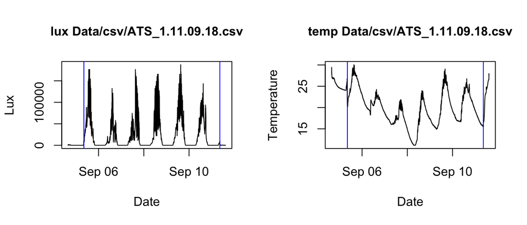

## Week 2 (ATS_2)

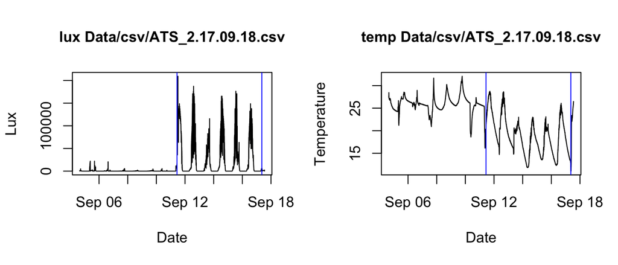

## Week 3 (ATS_1)

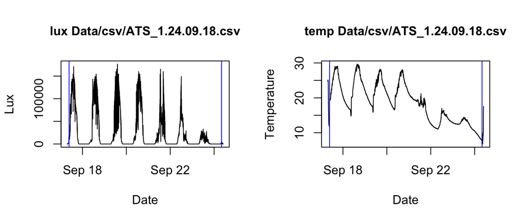

## Week 4 (ATS_2)

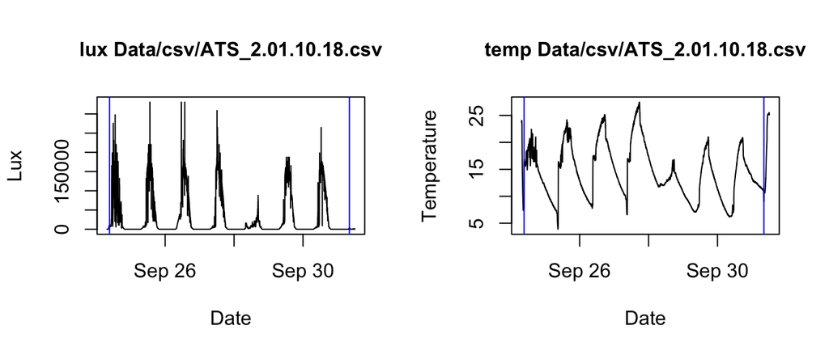

## Week 5 (ATS_1)

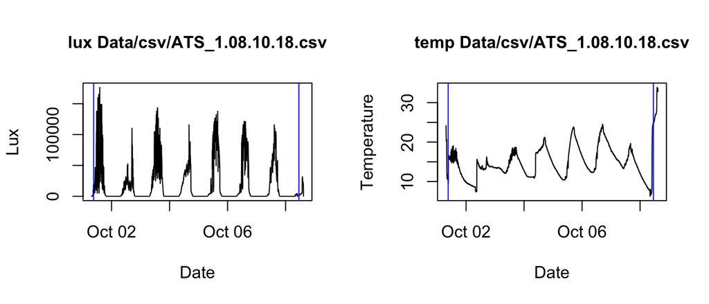

## Week 6 (ATS_2)

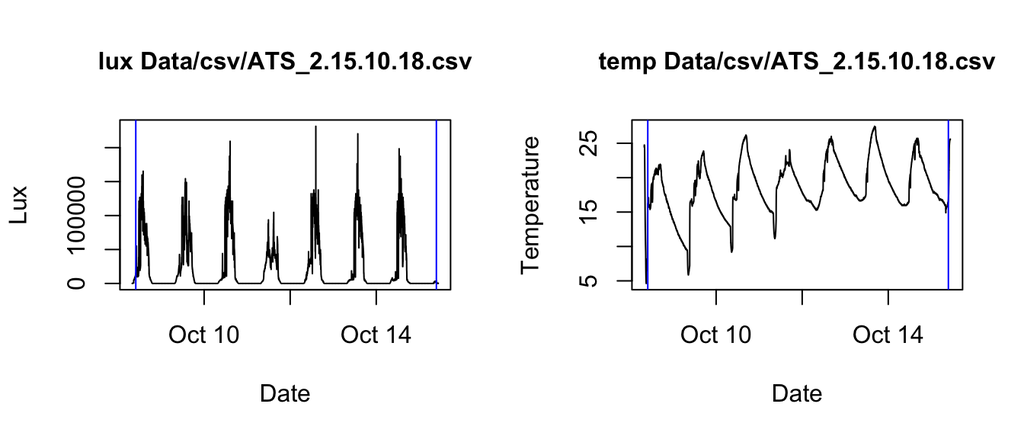

## Week 7 (ATS_1)

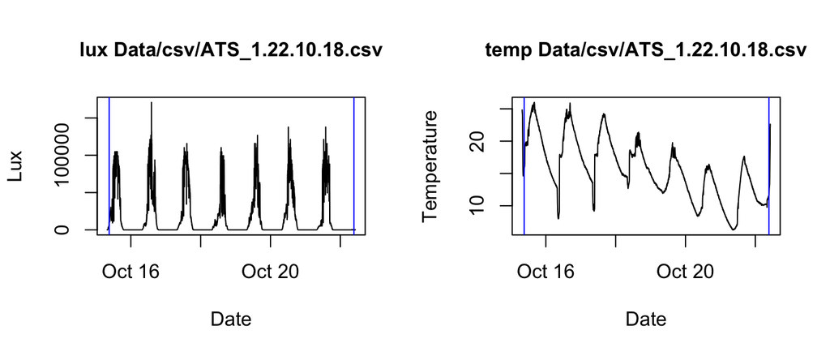

# Floway Chemistry & Biomass Productivity

On two occasions, samples were assayed both on the day they were taken and after freezing (Table 1). As the absolute differences between the readings for frozen and unfrozen samples was small, less than 5% except for two measurements, it was decided to freeze and accumulate samples for collective analysis rather than assay each sample on the day it was collected.

Differences among fresh and frozen samples

| before | PO4Pdelta | TNdelta | PO4Ppct | TNpct |
| --- | --- | --- | --- | --- |
| FALSE | 0.40 | 0.29 | 5.4869684 | 3.2842582 |
| TRUE | -0.10 | 0.10 | -0.9615385 | 1.0764263 |
| FALSE | -0.27 | 0.47 | -4.1284404 | 5.6085919 |
| TRUE | -0.17 | 0.02 | -1.7119839 | 0.2051282 |

# Biomass Composition Data

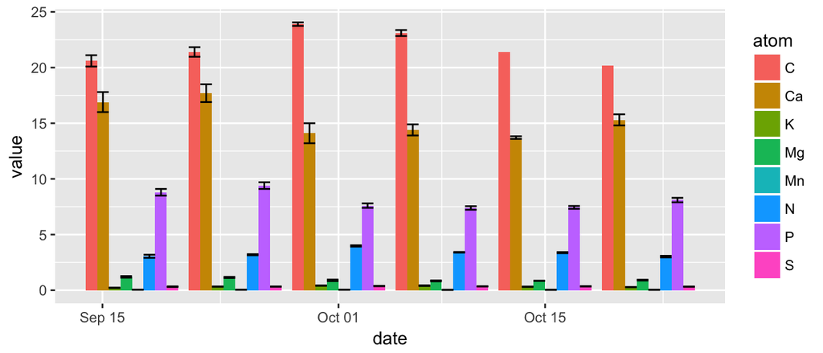

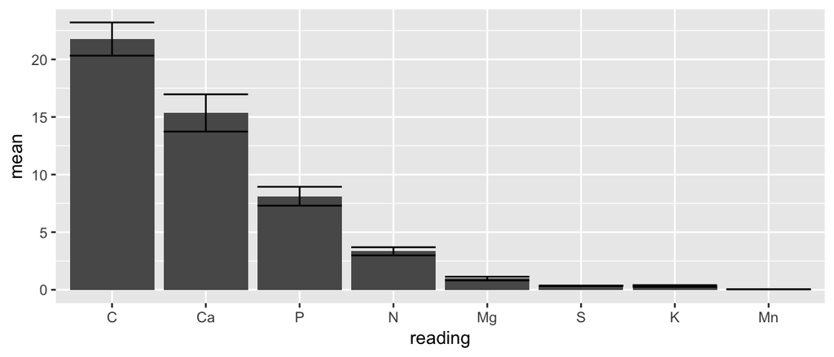

# Data Dictionaries

Data/csv/FZJAP2018 Biomass Composition.csv

| Column | Description |
| --- | --- |
| id | Observation ID |
| date | Harvest date |
| atom | Element assayed |
| wtprop | Mass proportion of element in sample |
| wtpropsd | Standard deviation of proportion with n = 2 |

Data/csv/FZJAP2018 Biomass Productivity.csv

| Column | Description |
| --- | --- |
| wet_biomass | Mass of total fresh biomass harvested |
| dry_biomass | Mass of total dried biomass |
| obsdate | Harvest date |

Data/csv/FZJAP2018 Temperature and Irradiance.csv

| Column | Description |
| --- | --- |
| datetime | Date and time of observation |
| temp | Temperature (°C) |
| lux | Irradiance (lux) |
| week | Week index |

Data/csv/FZJAP2018 Water Chemistry.csv

| Column | Description |
| --- | --- |
| datetime | Date and time of observation |
| before | Was this sample taken before or after water exchange? |
| PO4P | Soluble PO4, mg L-1 |
| TN | Total N, mg L-1 |
| pH | ph |
| frozen | Was this sample frozen? |
| assaydate | Date sample was assayed |
| obsdate | Observation date |

# Acknowledgement

This work was supported by the German Federal Ministry of Education and Research (BMBF) within the project Algnutrient-UrBioSol, Bioeconomy International FKZ031B0453A.

# References

Schreiber, Christina, Dominik Behrendt, Gregor Huber, Christian Pfaff, Janka Widzgowski, Bärbel Ackermann, Andreas Müller, Vilém Zachleder, Šárka Moudríková, and Peter Mojzeš. 2017. “Growth of Algal Biomass in Laboratory and in Large-Scale Algal Photobioreactors in the Temperate Climate of Western Germany.” *Bioresource Technology* 234 (June): 140–49. https://doi.org/10.1016/j.biortech.2017.03.028.

[^1]: Smithsonian Institution, Forschungszentrum Jülich
[^2]: Forschungszentrum Jülich